# Predictive Modeling of Heart Disease using Logistic Regression, Neural Networks, Decision Trees, and bagging Algorithms with ROC Analysis

Steven Raimondo

26-Oct-2024

# 1 Introduction

## 1.1 Background

Cardiovascular Disease (CVD) is the leading cause of mortality in the USA, making it essential not only to diagnosis CVD at the early stages but now with advanced computing, data collection, and statistical techniques to predict what individuals are at high risk. This analysis leverages a comprehensive dataset comprised of not only standard clinical lab values such as cholesterol, fasting blood sugar, and blood pressure, but also clinical measurement data was obtained such as exercise induced angina, electrocardiogram (ECG) readout data, and chest pain type. The combination of both lab and clinical measurements makes this dataset very comprehensive in key potential predictive variables of CVD.

This analysis was performed by implementing several predictive modelling techniques such as logistic regression, a neural network (Perceptron), decision trees, and a bagging algorithm. Subsequent Receiver Operating Characteristic (ROC) Curve analysis was performed for evaluation and determination of each methods predictive modelling to determine the optimal model for prediction of CVD.

### 1.1.1 Questions to be Addressed

What statistical technique best models the dataset in question to give us a prediction of whether an individual has CVD?

What variables are significant and how their relationships affect helping to predict which patients are at risk for CVD?

## 1.2 Working Data Set

The Heart dataset consists of 918 observations and 12 variables made up of both categorical and numeric variables that was preprocessed to recode some of the labels to better visualize the data and graphical outputs in the subsequent analysis.The dataset is comprised of both clinical lab variables and clinical measurement data derived from patients. The binary response variable in this dataset will be labelled ‘HeartDisease’ depicting whether that patient has heart disease or not. While the origin of the dataset is not known, it was deemed not necessary for this analysis as there was a comprehensive description of the variables provided on the data science community website called Kaggle. The following list includes the variable names, descriptions, type of variable, and outputs:

‘Age’: Patient’s age in years (Integer)

‘Sex’: Patient’s sex - Male or Female (Categorical)

‘ChestPainType’: Patient’s chest pain type - TA: Typical Angina, ATA: Atypical Angina, NAP: Non-Anginal Pain, ASY: Asymptomatic (Categorical)

‘RestingBP’: Resting blood pressure (mm Hg) (Integer)

‘Cholesterol’: Serum cholesterol reading (mm/dl) (Integer)

‘FastingBS’: Fasting blood glucose reading (> 120 mg/dl / <= 120 mg/dl) (Categorical)

‘RestingECG’: Resting ECG results (Normal: normal, ST: with ST-T wave abnormality, LVH: showing probable or definite left ventricular hypertrophy by Estes criteria) (Categorical)

‘MaxHR’: Maximum heart rate patient reached (Integer)

‘ExerciseAngina’: Exercise-induced angina (Yes or No) (Categorical)

‘Oldpeak’: old peak = ST (Numerical value measured in depression) (Numeric)

‘ST_Slope’: Slope of the peak exercise ST segment (Up, Flat, or Down) (Categorical)

‘HeartDisease’: (No or Yes) (Categorical)

An explanation for some of the not common variables was determined to be beneficial for readers of this analysis who are not familiar with some of the clinical meaning of the variables. Additionally, since there was no distinction made for how the restingbp was created, whether it was a combination of systolic and diastolic readings or simply one or the other and recorded as restingbp we will not make assumptions and simply refer to the variable as restingbp.

**ChestPainType** - Angina is short for Angina pectoris which is chest pain or discomfort due to coronary heart disease. Typical angina is pain that is substernal, jaw, and/or arm pressure-like pain which consistently occurs with exertion and consistently resolves within 15 minutes of rest and/or use of nitroglycerin(Cheng VY, Berman DS, Rozanski A, et al.). Atypical angina has is which patients present with nonanginal chest pain but are still symptomatic of cardiac ischemia issues. Non-Anginal Pain are patients that present chest pain but are not due to angina (cardio heart diseases). The chest pain could be due to gastrointestinal or muscoskeletal issues. Asymptomatic patients present with no chest pain.

**FastingBS** - While a fasting blood glucose reading of >125 mg/dl is defined by the Mayo Clinic as diabetic (Prediabetes - Diagnosis and treatment - Mayo Clinic. (n.d.)). Sutter Health defines it has > 120 mg/dl (Elevated blood sugar levels and diabetes | Sutter Health. (n.d.)). Therefore, we will use Sutter Health’s definition as our dataset has FastingBS as a binary variable without actual blood sugar values.

**Oldpeak** - Is a measurement of the ST depression induced by exercise relative to rest (Al Ahdal A, Rakhra M, Rajendran RR, et al.).

**ST_Slope** - The ST segment of the electrocardiogram (ECG) is the segment between the end of ventricular depolarization and beginning of ventricular repolarization on the ECG. Another way to put it is the ST segment represents the time from the myocardium maintains contraction to expel blood from the ventricles. The corresponding slope of the ST segment on the ECG can be either upward, flat, or downsloping. An upsloping ST segment is generally considered normal, while an ST slope which is horizontal is more characteristic of myocardial ischemia. Lastly, a downsloped is the worst prognosis and has been associated with cvd (Kashou AH, Basit H, Malik A. ST Segment). Therefore, being able to determine the different ST-slope a patient has on an ECG can help assist in identifying possible CVD.

# 2 Methodology

## 2.1 Logistic Regression

Logistic regression is a statistical technique used for modeling the probability of a binary outcome. We’ll use this technique in the subsequent analysis to assess the impact of various variables such as: Age, Sex, ST_Slope, RestingECG, and etc. on the likelihood of having cardiovascular disease represented by our dependent variable HeartDisease.

The logistic regression model allows us to estimate the odds of an outcome occuring via the logistic function in R by way of converting a linear relationship into a probability. The probability of this event allows us to predict, in this case whether a person will have HeartDisease or not.

The structural form of a logistic regression model is given by:

$logit(p) = \beta_0 + \beta_1 X_1 + \beta_2 X_2 +\beta_kX_k$.

These components of logistic regression consist of:

- $logit(p)$ is the log-odds of the probability of an event occurring.
- $\beta_0$ denotes the Y-intercept when $X$ is zero.
- $\beta_1, \beta_2, \beta_k$ are the coefficients associated with the explanatory variables
- $X_1, X_2, X_k$ are the explanatory variables

## 2.2 Single Layer Neural Network - Perceptron

The next statistical method employed in this comprehensive analysis involved the use of a single layer neural network - perceptron. This simple neural network is a supervised learning binary classification algorithm meant to mimic how a human brain processes information and is the simplest form of neural networks (Ezukwoke, K. 2019). Single layer Perceptron is very similar to logistic regression in that both give binary classifications outputs however has the ability to be extended into more complex multi-layer neural networks.The major elements of the single-layer perceptron involves the following:

**Input Layer:** Consists of one or more input neurons, that receives signals from external data.

**Weights:** Each input neuron has a corresponding weight, which helps represent the strength of the association between the input neuron and output neuron.

**Bias:** Added to the input layer to provide additional flexibility in modeling complex patterns

**Activation Function:** Determines the output of the perceptron based on the weighted sum of the inputs, threshold, and the bias term.

**Output:** A binary value, typically 0 or 1, which indicates what category the input data belongs to based on the threshold held by the activation function.

## 2.3 Decision Trees

A series of decision trees were used to implement machine learning algorithms that make decisions based on the value of the input features. Decision trees are a highly popular non parametric supervised learning statistically technique that is conceptually easily understood and visually self-explanatory statistical process to help answer yes and no decisions by way of nodes. They are highly versatile in that they can handle both categorical and continuous variables and are very efficient in breaking down the step by step process to a desired result by ways of splitting. However, due to the fact they are highly adaptable to fit any scenario and make it a split in the tree one must be careful as they are susceptible to over fitting if not mindful. We implemented two methods of splitting known as the Gini Index and Entropy. The Gini Index and Entropy are both measures of impurity where the Gini Index looks at the probability of being misclassified and chooses the smallest value for the split, whereas Entropy is based on information gained determining whether a split is worthwhile.

## 2.4 Bootstrap Method

The last statistical technique that was utilized in this analysis was that of an aggregated Bootstrap Method aka bagging. The Bootstrap Method is a powerful resampling technique that takes the original dataset and draws numerous samples from it allowing for replacement of observations. This is a relatively new but albeit very popular non-parametric method to deal with data where the underlying distribution is not known proposed by Efron in 1979 (B.Efron, 1979). The aggregated bagging technique is an ensemble machine learning process for this analysis takes the bootstrap samples (this analysis used 1000 samples) and subsequent predictions via logistic regression and assigns the final prediction. The combination of all these statistical techniques makes for a powerful model that can help reduce the variance in the data while also analyzing the most signficant explanatory variables of HeartDisease.

# 3 Exploratory Data Analysis

Exploratory Data Analysis (EDA) is a vital initial step in almost any data analysis to help assist with understanding the relationship of the variables, parameters of the dataset, and often offer insight that easily easily visualized via one method or another. We relayed on many different methods below to not only preprocess and assess our dataset but to glean insights into the relationships.

## 3.1 Handling Missing Values

The 1st part of the EDA that was undertaken was to examine whether we were dealing with any missing values for any variables in the dataset. We can see below there are no missing values in the Heart dataset.

```r
Missing_Values <- Heart.NEW[apply(is.na(Heart.NEW), 1, any), ]
print(Missing_Values)
```

```
 [1] Age            Sex            ChestPainType  RestingBP      Cholesterol
 [6] FastingBS      RestingECG     MaxHR          ExerciseAngina Oldpeak
[11] ST_Slope       HeartDisease
<0 rows> (or 0-length row.names)
```

## 3.2 Summary Statistics

Below is a summary printout of the Heart dataset. As previously noted we can see there are no missing values. Additionally, we can see there are a few variables with questionable summary statistics i.e:

**RestingBP** - The min. RestingBP is 0, with 1 observation being recorded for this.

**Cholesterol** - The min. cholesterol is 0, with 172 observations being recorded for this.

**MaxHR** - The MaxHR was only 60 which is a very low value for such a variable. As previously noted in the introduction, the origin of the dataset was not available to determine the accuracy of this dataset. However, after a closer look at the variable a determination was made since there were a fair amount of MaxHR <100 and the type of dataset we’re dealing with (Heart Disease) perhaps the patients were not physically able to exert themselves safely to give a strong MaxHR reading. The variable was left as is as to not to manipulate the dataset in such a way that could bias the results. Should the low MaxHR readings be a sign of HeartDisease this will be determined in subsequent analsysis in this paper.

Both of the min values for RestingBP and Cholesterol are physically impossible and probable that the readings were not available (no lab tests done for cholesterol). Therefore additional EDA was conducted on these observations and appropriate measures were taken in the sections below.

Some points of note from the summary output:

- The patients ages range from 28 to 77 which is a wide range with a mean and mean both around 54 years. A person who is 28 years old is very different physically from a person who is 77 years old.
- The dataset is comprised of ~78% males whereas females only make up ~22% of the observations.
- The variable cholesterol has a wide range of values where excluding the perceived missed values the 1st quadrant was 173.2 whereas the max came out to be 603.
- The clinical measurements, Oldpeak, ST_Slope, ChestPainType, and Exercise Angina, all have a good distribution and will be looked at more closely in subsequent sections.

```r
summary(Heart.NEW)
```

```
      Age            Sex      ChestPainType   RestingBP      Cholesterol
 Min.   :28.00   Male  :725   TA : 46       Min.   :  0.0   Min.   :  0.0
 1st Qu.:47.00   Female:193   ATA:173       1st Qu.:120.0   1st Qu.:173.2
 Median :54.00                NAP:203       Median :130.0   Median :223.0
 Mean   :53.51                ASY:496       Mean   :132.4   Mean   :198.8
 3rd Qu.:60.00                              3rd Qu.:140.0   3rd Qu.:267.0
 Max.   :77.00                              Max.   :200.0   Max.   :603.0
        FastingBS    RestingECG      MaxHR       ExerciseAngina
 <= 120 mg/dl:704   Normal:552   Min.   : 60.0   No :547
 > 120 mg/dl :214   ST    :178   1st Qu.:120.0   Yes:371
                    LVH   :188   Median :138.0
                                 Mean   :136.8
                                 3rd Qu.:156.0
                                 Max.   :202.0
    Oldpeak        ST_Slope   HeartDisease
 Min.   :-2.6000   Up  :395   No :410
 1st Qu.: 0.0000   Flat:460   Yes:508
 Median : 0.6000   Down: 63
 Mean   : 0.8874
 3rd Qu.: 1.5000
 Max.   : 6.2000
```

```r
sum(Heart.NEW$RestingBP == 0)
```

```
[1] 1
```

```r
sum(Heart.NEW$Cholesterol == 0)
```

```
[1] 172
```

### 3.2.1 Data Manipulation

```r
sum(Heart$RestingBP == 0)
```

```
[1] 0
```

```r
sum(Heart$Cholesterol == 0)
```

```
[1] 0
```

## 3.3 Accessing Pairwise Plots

The first step of the EDA was done via pairwise plots to see what/if any meaningful relationships exist between the continuous variables. We see in the pairwise plots below that MaxHR and Age have a moderately inverse relationship where as an individual ages the MaxHr decreases. On the other hand RestingBP and have a less moderate but still visible positive relationship where as an individual ages their RestingBP increases. The other correlation relationship to note was the positive relationship of OldPeak and age where as Age increases so does the OldPeak values. While the other correlations shown were not very strong, we do see what we would expect in terms of positive vs inverse relationships. We see that as an indivudals MaxHR increases their RestingBP decreases which is typically a sign of being physically fit.

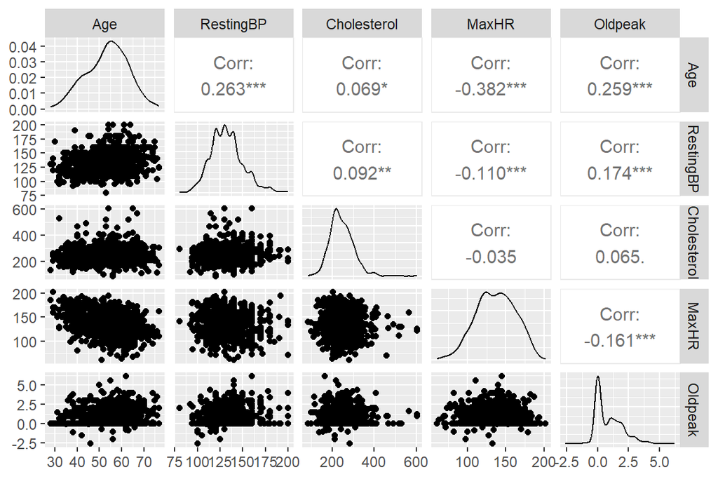

```r
library(GGally)
PairwisePlots = Heart[, c(1,4:5,8,10)]
ggpairs(PairwisePlots)
```

```r
cor(PairwisePlots)
```

```
                    Age  RestingBP Cholesterol       MaxHR     Oldpeak
Age          1.00000000  0.2630651  0.06892987 -0.38204468  0.25861154
RestingBP    0.26306506  1.0000000  0.09158270 -0.10972858  0.17416594
Cholesterol  0.06892987  0.0915827  1.00000000 -0.03492668  0.06452308
MaxHR       -0.38204468 -0.1097286 -0.03492668  1.00000000 -0.16069055
Oldpeak      0.25861154  0.1741659  0.06452308 -0.16069055  1.00000000
```

In order to view the continuous variables together a combined boxplot was used to determine if there were any additional outliers we should take note of since we have already imputed the missing values earlier. The combined boxplot also gives a very nice visualization of the data and how it’s distributed. We see there are quite a few outliers for the variable cholesterol. While researchers should always take note of outliers, some individuals may have very high cholesterol readings and without access to the originator of the dataset, we should not discount these outliers as errors and keep them in the subsequent analysis.

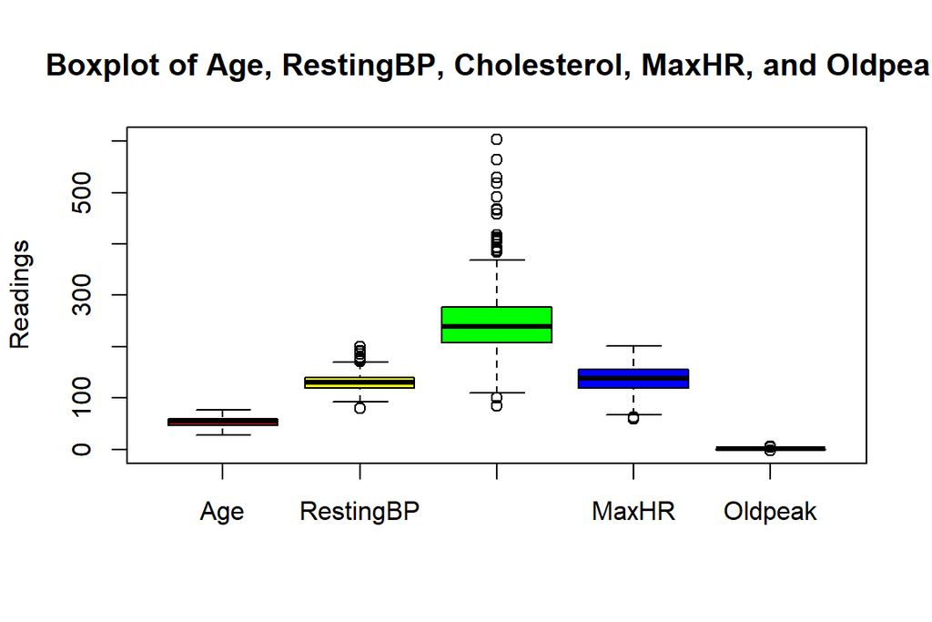

```r
boxplot(Heart$Age, Heart$RestingBP, Heart$Cholesterol, Heart$MaxHR, Heart$Oldpeak,
   main = "Boxplot of Age, RestingBP, Cholesterol, MaxHR, and Oldpeak",
   ylab = "Readings",
   col = c("Red", "Yellow", "Green", "Blue", "Orange"),
   names = c("Age", "RestingBP", "Cholesterol", "MaxHR", "Oldpeak"))
```

Next we examined the density Curves of the numeric variables that allows us to view the distribution of said numeric variables and while we’re not performing linear regression and will not test for skewness, a visualization of the data is very beneficial for both the researcher and reader to understand the complete data. Below are are the density curves for the five numeric variables: Age, RestingBP, Cholesterol, MaxHR, and Oldpeak.

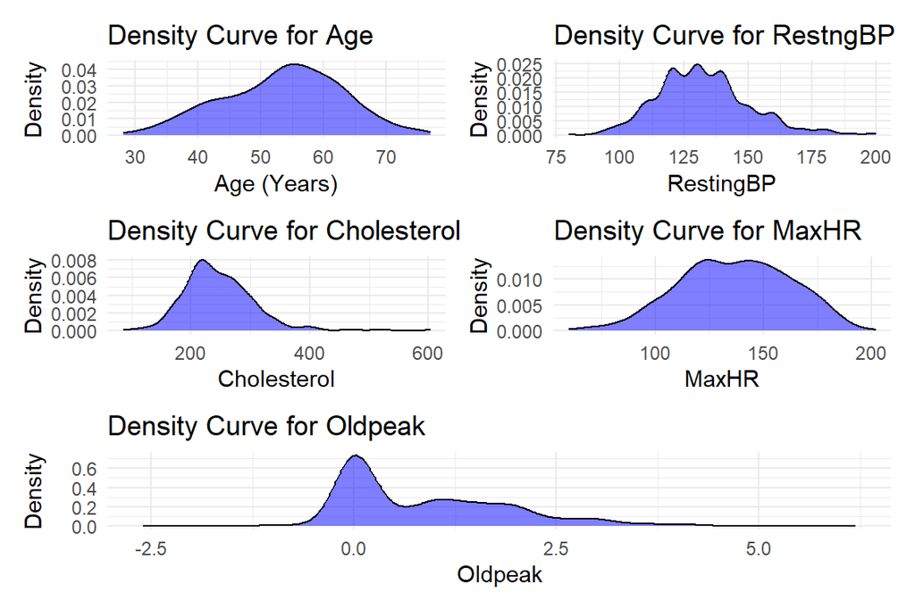

```r
library(ggplot2)
library(patchwork)

plot1 <- ggplot(Heart, aes(x = Age)) +
  geom_density(fill = "blue", alpha = 0.5) +
  labs(title = "Density Curve for Age", x = "Age (Years)", y = "Density") +
  theme_minimal()

plot2 <- ggplot(Heart, aes(x = RestingBP)) +
  geom_density(fill = "blue", alpha = 0.5) +
  labs(title = "Density Curve for RestngBP", x = "RestingBP", y = "Density") +
  theme_minimal()

plot3 <- ggplot(Heart, aes(x = Cholesterol)) +
  geom_density(fill = "blue", alpha = 0.5) +
  labs(title = "Density Curve for Cholesterol", x = "Cholesterol", y = "Density") +
  theme_minimal()

plot4 <- ggplot(Heart, aes(x = MaxHR)) +
  geom_density(fill = "blue", alpha = 0.5) +
  labs(title = "Density Curve for MaxHR", x = "MaxHR", y = "Density") +
  theme_minimal()

plot5 <- ggplot(Heart, aes(x = Oldpeak)) +
  geom_density(fill = "blue", alpha = 0.5) +
  labs(title = "Density Curve for Oldpeak", x = "Oldpeak", y = "Density") +
  theme_minimal()
(plot1 + plot2) / (plot3 + plot4) / (plot5)
```

Looking at the categorical variables distribution was the next step in the EDA. The dataset is comprised of over 3x males to females with the former comprising of ~78% of the observations and the latter ~22%. However, looking at the distribution of our response variable: HeartDisease we see that it is fairly even.

We also see that while there are 3x the amount of individuals without what is defined as diabetes there is still a fair amount of individuals (214) in the dataset with diabetes representing ~23% of the study population. The majority of the individuals did not have exercise induced Angina. However, 371 out of the 918 individuals did representing ~40% of the study population.

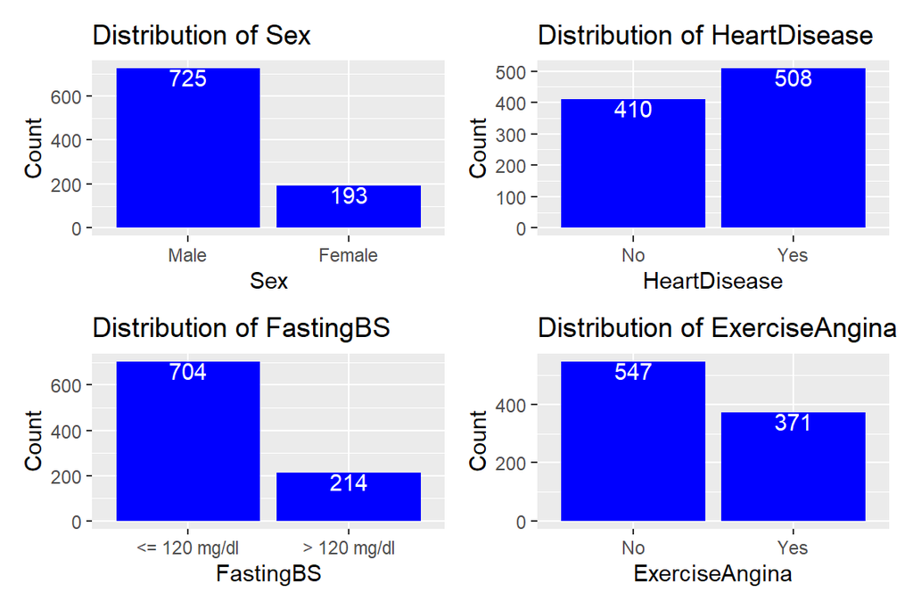

```r
plot6 <- ggplot(Heart, aes(x = Sex)) +
  geom_bar(fill = "Blue") +
  geom_text(stat = 'count', aes(label = ..count..), vjust = 1, color = "White") +
  labs(title = "Distribution of Sex", x = "Sex", y = "Count")

plot7 <- ggplot(Heart, aes(x = HeartDisease)) +
  geom_bar(fill = "Blue") +
  geom_text(stat = 'count', aes(label = ..count..), vjust = 1, color = "White") +
  labs(title = "Distribution of HeartDisease", x = "HeartDisease", y = "Count")

plot8 <- ggplot(Heart, aes(x = FastingBS)) +
  geom_bar(fill = "Blue") +
  geom_text(stat = 'count', aes(label = ..count..), vjust = 1, color = "White") +
  labs(title = "Distribution of FastingBS", x = "FastingBS", y = "Count")

plot9 <- ggplot(Heart, aes(x = ExerciseAngina)) +
  geom_bar(fill = "Blue") +
  geom_text(stat = 'count', aes(label = ..count..), vjust = 1, color = "White") +
  labs(title = "Distribution of ExerciseAngina", x = "ExerciseAngina", y = "Count")

(plot6 + plot7) / (plot8 + plot9)
```

The next group of bar graphs shows that approximately half of the individuals had asymptomatic chest pain and the combination of TA, ATA, and NAP associated ChestPain add up to the other half of the individuals. Additionally, while the RestingECG showed the majority of individuals had normal readouts there was evenly distributed ‘non-normal’ readouts of ST-wave abnormality and left ventricular hypertrophy with 178 and 188 respectively. Lastly, the ST-Slope variable shows that most of the indivuals showing either a flat or up slope with a few individuals displaying a downward slope.

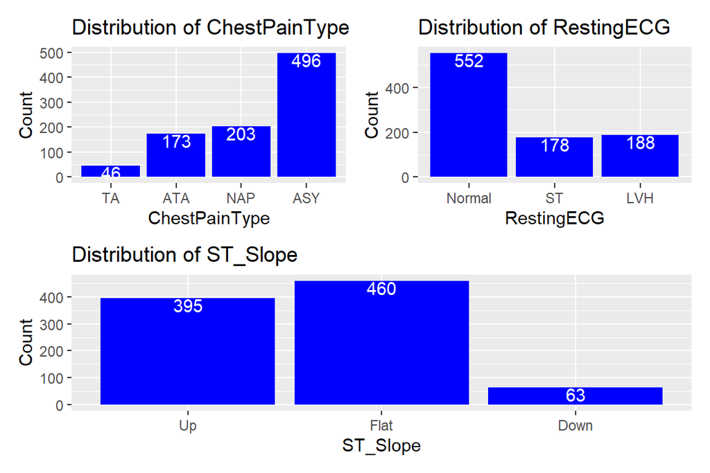

```r
plot10 <- ggplot(Heart, aes(x = ChestPainType)) +
  geom_bar(fill = "Blue") +
  geom_text(stat = 'count', aes(label = ..count..), vjust = 1, color = "White") +
  labs(title = "Distribution of ChestPainType", x = "ChestPainType", y = "Count")

plot11 <- ggplot(Heart, aes(x = RestingECG)) +
  geom_bar(fill = "Blue") +
  geom_text(stat = 'count', aes(label = ..count..), vjust = 1, color = "White") +
  labs(title = "Distribution of RestingECG", x = "RestingECG", y = "Count")

plot12 <- ggplot(Heart, aes(x = ST_Slope)) +
  geom_bar(fill = "Blue") +
  geom_text(stat = 'count', aes(label = ..count..), vjust = 1, color = "White") +
  labs(title = "Distribution of ST_Slope", x = "ST_Slope", y = "Count")

(plot10 + plot11) / (plot12)
```

Next we implemented a series of boxplots stratifying by the response variable: HeartDisease. We see for Age that those with HeartDisease overall were slightly older than those without HeartDisease. A surprising find was there seemed to be no difference (neglible) in individuals cholesterol levels whether they had HeartDisease or didn’t. The MaxHR and RestingBP boxplots were consistent with what we expected to find, in that individuals without HeartDisease would have a higher MaxHR and a lower RestingBP. The old peak also had a noticeable difference in individuals with and without Heart Disease. It’s worth noting thought that a fair amount of values of OldPeak were found to be 0. This researcher was unable to conclude whether the value is truly 0 or might be that this particular test was not conducted for a patient, like we hypothesized with the cholesterol levels. An individual is certainly capable of having a 0 reading which makes it difficult to determine whether the patient actually had the test or didn’t. We’ll proceed cautiously with this variable but will treat it with skepticism since it’s origins can’t be confirmed.

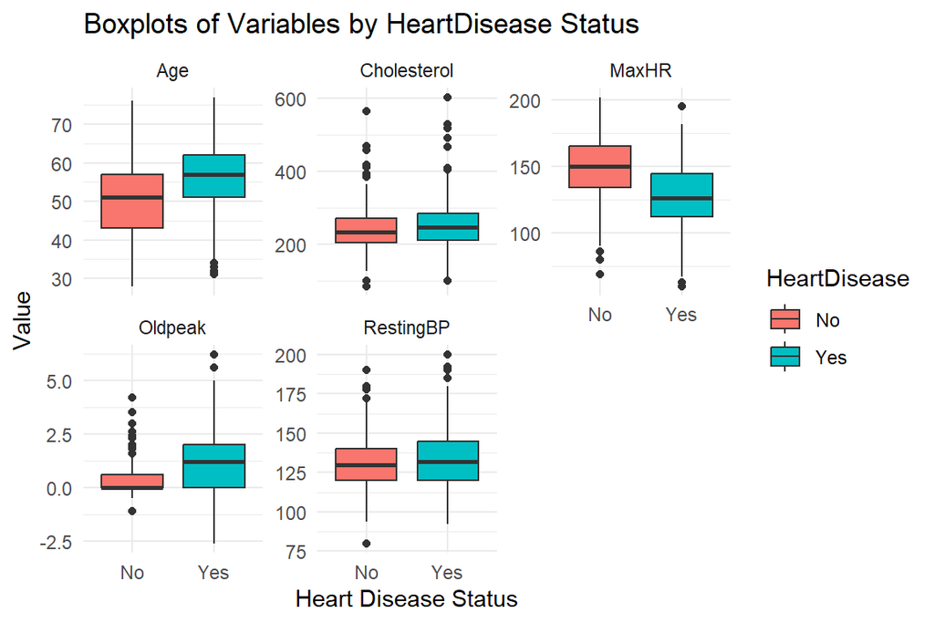

```r
library(ggplot2)
library(tidyr)

Heart_long <- Heart %>%
  gather(key = "Variable", value = "Value", Age, RestingBP, Cholesterol, MaxHR, Oldpeak)

ggplot(Heart_long, aes(x = HeartDisease, y = Value, fill = HeartDisease)) +
  geom_boxplot() +
  facet_wrap(~ Variable, scales = "free_y") +
  labs(title = "Boxplots of Variables by HeartDisease Status",
       x = "Heart Disease Status",
       y = "Value") +
  theme_minimal()
```

```r
library(knitr)

Heart_FastingBS <- table(Heart$HeartDisease, Heart$FastingBS)
Heart_Sex <- table(Heart$HeartDisease, Heart$Sex)
Heart_ChestPainType <- table(Heart$HeartDisease, Heart$ChestPainType)
Heart_RestingECG <- table(Heart$HeartDisease, Heart$RestingECG)

kable(Heart_FastingBS, caption = "HeartDisease and Fasting Blood Sugar Frequency Table")
```

HeartDisease and Fasting Blood Sugar Frequency Table

|  | <= 120 mg/dl | > 120 mg/dl |
| --- | --- | --- |
| No | 366 | 44 |
| Yes | 338 | 170 |

```r
kable(Heart_Sex, caption = "HeartDisease and Sex Frequency Table")
```

HeartDisease and Sex Frequency Table

|  | Male | Female |
| --- | --- | --- |
| No | 267 | 143 |
| Yes | 458 | 50 |

```r
kable(Heart_ChestPainType, caption = "HeartDisease and Chest Pain Type Frequency Table")
```

HeartDisease and Chest Pain Type Frequency Table

|  | TA | ATA | NAP | ASY |
| --- | --- | --- | --- | --- |
| No | 26 | 149 | 131 | 104 |
| Yes | 20 | 24 | 72 | 392 |

```r
kable(Heart_RestingECG, caption = "HeartDisease and Resting ECG Frequency Table")
```

HeartDisease and Resting ECG Frequency Table

|  | Normal | ST | LVH |
| --- | --- | --- | --- |
| No | 267 | 61 | 82 |
| Yes | 285 | 117 | 106 |

# 4 Statistical Modeling

## 4.1 Logistic Regression Modeling

Our first formal prediction modelling was done via logistic regression which is a statistical method used for modeling a binary outcome. We used our response variable of HeartDisease which states whether an individuals has the presence of HeartDisease coded as (1 - Yes, 0 - No). The model utilizes the other variables in the dataset as predictor variables that will help predict the probability of an individual with certain predictor variable characteristics and determine the probability based on a predetermined threshold (usually 0.5) that a person will have heart disease or not and will be assigned one of the output values previously mentioned.

Below we fit the reduced and full models, with the results hidden as to not take up an inordinate amount of space with interim models. The reduced model has variables chosen of particular interest. The variables Age, Sex, MaxHR, Cholesterol, and RestingBP were chosen due to the fact these are easily obtained measurements either via a simple physical exam and CompleteBloodCount (CBC). The reduced model showed that the RestingBP was insignificant at the 0.05 level with a p-value of 0.202390. The remaining variables were deemed to be statistically significant. The full model was able to provide some additional insights into the significance of the explanatory variables showing that Age, RestingBP, MaxHR, and RestingECG were all shown to be statistically insigifant at the 0.05 level.

```r
library(MASS)
reducedModel <- glm(HeartDisease ~ Age + Sex + MaxHR + Cholesterol + RestingBP,
family = binomial(link = "logit"), data = Heart)
summary(reducedModel)

fullModel <- glm(HeartDisease ~ .,
family = binomial(link = "logit"),data = Heart)
summary(fullModel)
```

Stepwise selection Modeling is a powerful tool that allows R to add/remove a variable at each step in the process while at the same time evaluating the significance of the variables in the model with each addition/removal and adjusting as needed. We see the read out of the stepwise model that while there were a couple variables kept in the model even though they were deemed to be insignificant. The reason behind this could be due to the fact that there is some interaction/relationship of these variables with other signficaint variables in the model and thus removing them would also alter the model in a significant way.

```r
stepwiseModel <- step(glm(HeartDisease ~ ., family = binomial(link = "logit"), data = Heart),
direction = "both", trace = 0)
summary(stepwiseModel)
```

```
Call:
glm(formula = HeartDisease ~ Age + Sex + ChestPainType + FastingBS +
    MaxHR + ExerciseAngina + Oldpeak + ST_Slope, family = binomial(link = "logit"),
    data = Heart)

Coefficients:
                      Estimate Std. Error z value Pr(>|z|)
(Intercept)          -2.284999   1.197229  -1.909 0.056317 .
Age                   0.019721   0.012419   1.588 0.112284
SexFemale            -1.581774   0.273225  -5.789 7.07e-09 ***
ChestPainTypeATA     -0.441053   0.483995  -0.911 0.362149
ChestPainTypeNAP     -0.166091   0.436461  -0.381 0.703544
ChestPainTypeASY      1.463211   0.424822   3.444 0.000573 ***
FastingBS> 120 mg/dl  1.338178   0.264458   5.060 4.19e-07 ***
MaxHR                -0.007378   0.004741  -1.556 0.119655
ExerciseAnginaYes     0.867545   0.238203   3.642 0.000270 ***
Oldpeak               0.363417   0.115014   3.160 0.001579 **
ST_SlopeFlat          2.366389   0.238600   9.918  < 2e-16 ***
ST_SlopeDown          1.078653   0.441829   2.441 0.014633 *
---
Signif. codes:  0 '***' 0.001 '**' 0.01 '*' 0.05 '.' 0.1 ' ' 1

(Dispersion parameter for binomial family taken to be 1)

    Null deviance: 1262.14  on 917  degrees of freedom
Residual deviance:  609.16  on 906  degrees of freedom
AIC: 633.16

Number of Fisher Scoring iterations: 5
```

```r
finalModel <- glm(HeartDisease ~ Sex + ST_Slope + FastingBS + ExerciseAngina + Oldpeak, family = binomial(link = "logit"),data = Heart)
summary(finalModel)
```

```
Call:
glm(formula = HeartDisease ~ Sex + ST_Slope + FastingBS + ExerciseAngina +
    Oldpeak, family = binomial(link = "logit"), data = Heart)

Coefficients:
                     Estimate Std. Error z value Pr(>|z|)
(Intercept)           -1.9240     0.1748 -11.009  < 2e-16 ***
SexFemale             -1.6395     0.2469  -6.642 3.10e-11 ***
ST_SlopeFlat           2.4947     0.2128  11.724  < 2e-16 ***
ST_SlopeDown           1.2074     0.4012   3.010  0.00262 **
FastingBS> 120 mg/dl   1.4974     0.2436   6.146 7.95e-10 ***
ExerciseAnginaYes      1.5047     0.2139   7.034 2.01e-12 ***
Oldpeak                0.4170     0.1051   3.968 7.26e-05 ***
---
Signif. codes:  0 '***' 0.001 '**' 0.01 '*' 0.05 '.' 0.1 ' ' 1

(Dispersion parameter for binomial family taken to be 1)

    Null deviance: 1262.14  on 917  degrees of freedom
Residual deviance:  688.52  on 911  degrees of freedom
AIC: 702.52

Number of Fisher Scoring iterations: 5
```

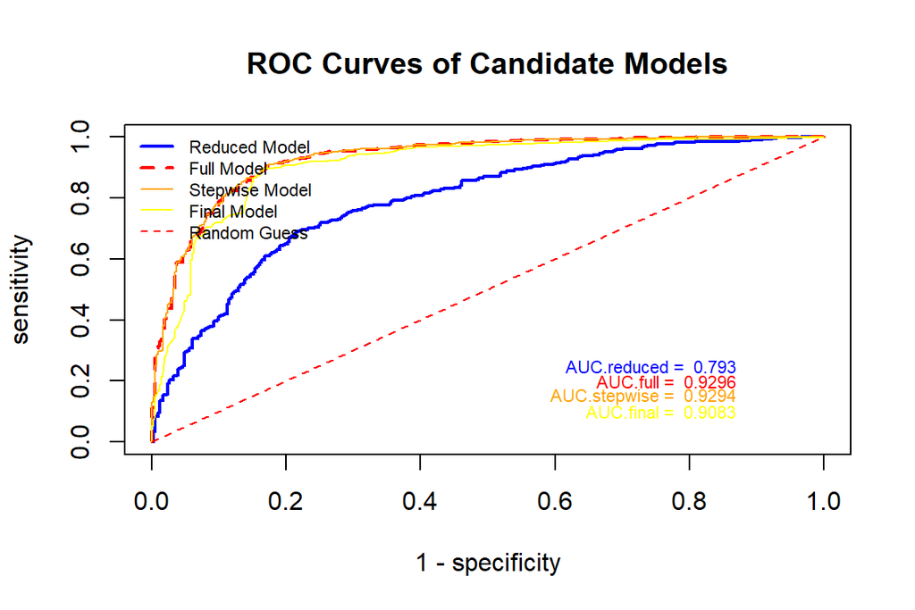

```r
library(pROC)
preReduced = predict(reducedModel, newdata = Heart, type = "response")
predfullModel = predict(fullModel, newdata = Heart, type = "response")
predstepwise = predict(stepwiseModel, newdata = Heart, type = "response")
predfinal = predict(finalModel, newdata = Heart, type = "response")

prediction.reduced = preReduced
prediction.full = predfullModel
prediction.stepwise = predstepwise
prediction.final = predfinal

category = Heart$HeartDisease == 'Yes'

ROCobj.reduced <- roc(category, prediction.reduced)
ROCobj.full <- roc(category, prediction.full)
ROCobj.stepwise <- roc(category, prediction.stepwise)
ROCobj.final <- roc(category, prediction.final)

reducedAUC = ROCobj.reduced$auc
fullAUC = ROCobj.full$auc
stepwiseAUC = ROCobj.stepwise$auc
finalAUC = ROCobj.final$auc

sen.reduced = ROCobj.reduced$sensitivities
fnr.reduced = 1 - ROCobj.reduced$specificities

sen.full = ROCobj.full$sensitivities
fnr.full = 1 - ROCobj.full$specificities

sen.stepwise = ROCobj.stepwise$sensitivities
fnr.stepwise = 1 - ROCobj.stepwise$specificities

sen.final = ROCobj.final$sensitivities
fnr.final = 1 - ROCobj.final$specificities

colors = c("Blue", "Red", "Orange", "Yellow")

plot(fnr.reduced, sen.reduced, type = "l", lwd = 2, col = colors[1],
     xlim = c(0, 1), ylim = c(0, 1),
     xlab = "1 - specificity", ylab = "sensitivity",
     main = "ROC Curves of Candidate Models")
lines(fnr.full, sen.full, lwd = 2, lty = 2, col = colors[2])
lines(fnr.stepwise, sen.stepwise, lwd = 1, col = colors[3])
lines(fnr.final, sen.final, lwd = 1, col = colors[4])
segments(0, 0, 1, 1, lwd = 1, col = "red", lty = 2)


legend("topleft", c("Reduced Model", "Full Model", "Stepwise Model", "Final Model", "Random Guess"),
       col = c(colors, "red"), lwd = c(2, 2, 1, 1, 1),
       lty = c(1, 2, 1, 1, 2), bty = "n", cex = 0.7)

text(0.87, 0.25, paste("AUC.reduced = ", round(reducedAUC, 4)), col = colors[1], cex = 0.7, adj = 1)
text(0.87, 0.20, paste("AUC.full = ", round(fullAUC, 4)), col = colors[2], cex = 0.7, adj = 1)
text(0.87, 0.15, paste("AUC.stepwise = ", round(stepwiseAUC, 4)), col = colors[3], cex = 0.7, adj = 1)
text(0.87, 0.10, paste("AUC.final = ", round(finalAUC, 4)), col = colors[4], cex = 0.7, adj = 1)
```

## 4.2 Single Layer Neural Network - Perceptron

The first step of the single layer neural network approach, which we’ll refer to hereon out as Perceptron is to convert the categorical variables to binary variables, some of which take a bit more work since there are several levels to the variable if used in a dummy format. We used the mutate function to transform the ChestPain, RestingECG, and ST_Slope variables to accommodate the requirements. We lastly scalled the continuous variables: age, restingBP, Cholesterol, MaxHR, and OldPeak. The subsequent colnames were given as output along with the colnames to be used in the implicit method as a model matrix automatically defining dummy variables.

```r
Hearts <- Heart

Hearts$Sex <- ifelse(Hearts$Sex == "Male", 1, 0)
Hearts$ExerciseAngina <- ifelse(Hearts$ExerciseAngina == "Yes", 1, 0)
Hearts$FastingBS <- ifelse(Hearts$FastingBS == "> 120 mg/dl", 1, 0)
Hearts$HeartDisease <- ifelse(Hearts$HeartDisease == "Yes", 1, 0)

Hearts <- Hearts %>%
  mutate(ChestPainTypeATA = ifelse(ChestPainType == "ATA", 1, 0), ChestPainTypeASY = ifelse(ChestPainType == "ASY", 1, 0),
  ChestPainTypeNAP = ifelse(ChestPainType == "NAP", 1, 0),
  RestingECGNormal = ifelse(RestingECG == "Normal", 1, 0), RestingECGST = ifelse(RestingECG == "ST", 1, 0),
  ST_SlopeUp = ifelse(ST_Slope == "Up", 1, 0), ST_SlopeFlat = ifelse(ST_Slope == "Flat", 1, 0),ST_SlopeDown = ifelse(ST_Slope == "Down", 1, 0))

scaled_data <- scale(Hearts[, c("Age", "RestingBP", "Cholesterol", "MaxHR", "Oldpeak")])

Heart_Perceptron <- cbind(scaled_data, Hearts[, c("Sex", "FastingBS", "ExerciseAngina", "ChestPainTypeATA", "ChestPainTypeASY", "ChestPainTypeNAP",
 "RestingECGNormal", "RestingECGST", "ST_SlopeUp", "ST_SlopeFlat", "ST_SlopeDown", "HeartDisease")])

implicitFormula <- model.matrix(~., data = Heart_Perceptron)
colnames(implicitFormula)
```

```
 [1] "(Intercept)"      "Age"              "RestingBP"        "Cholesterol"
 [5] "MaxHR"            "Oldpeak"          "Sex"              "FastingBS"
 [9] "ExerciseAngina"   "ChestPainTypeATA" "ChestPainTypeASY" "ChestPainTypeNAP"
[13] "RestingECGNormal" "RestingECGST"     "ST_SlopeUp"       "ST_SlopeFlat"
[17] "ST_SlopeDown"     "HeartDisease"
```

We use the below formula in the nuralnet() function.

```r
columnNames = colnames(implicitFormula)
columnList = paste(columnNames[-c(1,length(columnNames))], collapse = "+")
columnList = paste(c(columnNames[length(columnNames)],"~",columnList), collapse="")
modelFormula = formula(columnList)
modelFormula
```

```
HeartDisease ~ Age + RestingBP + Cholesterol + MaxHR + Oldpeak +
    Sex + FastingBS + ExerciseAngina + ChestPainTypeATA + ChestPainTypeASY +
    ChestPainTypeNAP + RestingECGNormal + RestingECGST + ST_SlopeUp +
    ST_SlopeFlat + ST_SlopeDown
```

The next step was to use the modelFormula in the neuralnet function and we can see thethe sigmoid activation function expressed as act.fct, in this case we set it to logistic. The resulting table is an estimate of the weights for each of the predictor variables.

```r
NetworkModel = neuralnet(modelFormula,
  data = implicitFormula,
  hidden = 1,
  act.fct = "logistic",linear.output = FALSE)
kable(NetworkModel$result.matrix)
```

| error | 45.4112455 |
| --- | --- |
| reached.threshold | 0.0097999 |
| steps | 655.0000000 |
| Intercept.to.1layhid1 | 1.8815454 |
| Age.to.1layhid1 | -0.2494982 |
| RestingBP.to.1layhid1 | 0.2468976 |
| Cholesterol.to.1layhid1 | -0.0563946 |
| MaxHR.to.1layhid1 | 0.1876644 |
| Oldpeak.to.1layhid1 | -0.6153632 |
| Sex.to.1layhid1 | -2.0082839 |
| FastingBS.to.1layhid1 | -1.6003053 |
| ExerciseAngina.to.1layhid1 | -1.4129547 |
| ChestPainTypeATA.to.1layhid1 | 0.5936211 |
| ChestPainTypeASY.to.1layhid1 | -1.3990309 |
| ChestPainTypeNAP.to.1layhid1 | 0.3331521 |
| RestingECGNormal.to.1layhid1 | -0.9295911 |
| RestingECGST.to.1layhid1 | -0.7885391 |
| ST_SlopeUp.to.1layhid1 | 2.6409645 |
| ST_SlopeFlat.to.1layhid1 | -0.3697473 |
| ST_SlopeDown.to.1layhid1 | 1.7989295 |
| Intercept.to.HeartDisease | 2.5473015 |
| 1layhid1.to.HeartDisease | -5.6116641 |

We then create a plot of the Perceptron model using these weights and a plotting function. We can see much how we described in the introduction how we discussed input data, and weights we see the visual representation of this explanation.

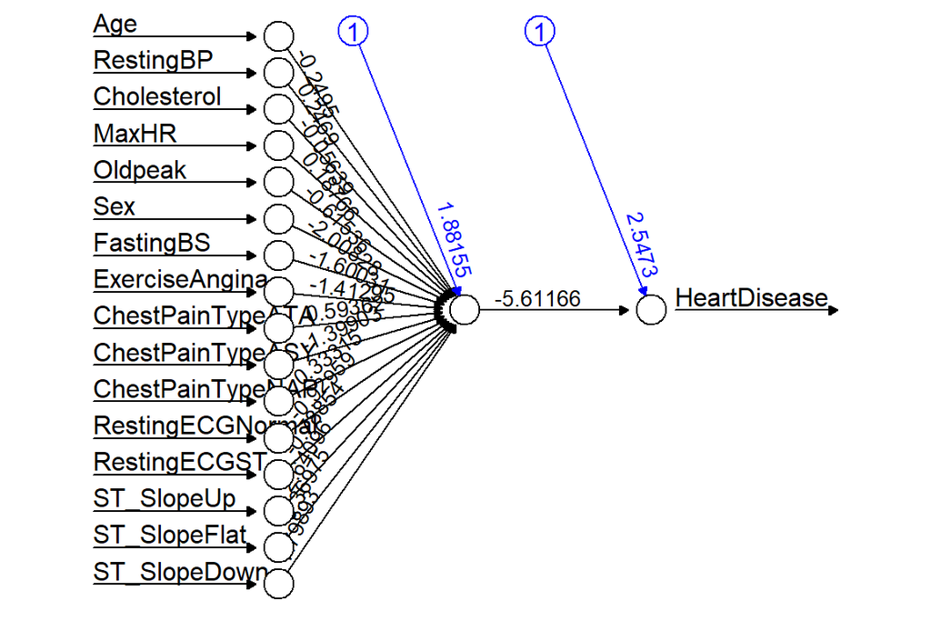

```r
plot(NetworkModel, rep="best")
```

Lastly, in orrder to compare our Perceptron model to the logistic models we modeled earlier, subsequent ROC analysis was performed on all 5 models. We can see the Perceptron model landed inbetween our AUC.final model and AUC.full & stepwise models (discounting reduced model). The Perceptron model came in at 0.9249 which is quite robust given the relatively little amount of work that is needed to perform it. This is certainly a good model to consider for future use.

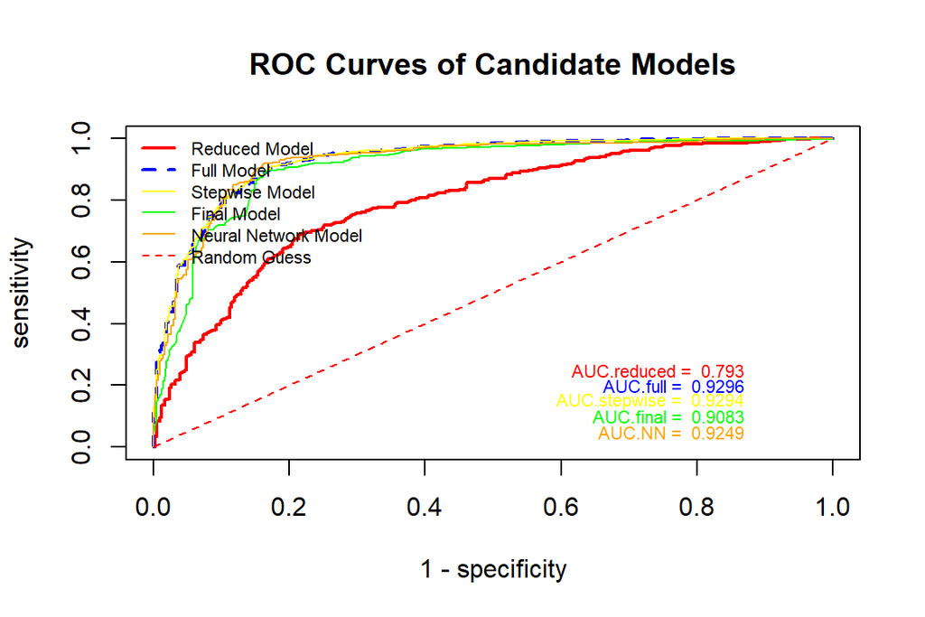

```r
library(pROC)
library(neuralnet)

preReduced = predict(reducedModel, newdata = Heart, type = "response")
predfullModel = predict(fullModel, newdata = Heart, type = "response")
predstepwise = predict(stepwiseModel, newdata = Heart, type = "response")
predfinal = predict(finalModel, newdata = Heart, type = "response")
predNN = predict(NetworkModel, newdata = implicitFormula, type = "response")

prediction.reduced = preReduced
prediction.full = predfullModel
prediction.stepwise = predstepwise
prediction.final = predfinal
prediction.NN = predNN

category = Heart$HeartDisease == 'Yes'

ROCobj.reduced <- roc(category, prediction.reduced)
ROCobj.full <- roc(category, prediction.full)
ROCobj.stepwise <- roc(category, prediction.stepwise)
ROCobj.final <- roc(category, prediction.final)
ROCobj.NN <- roc(category, prediction.NN)

reducedAUC = ROCobj.reduced$auc
fullAUC = ROCobj.full$auc
stepwiseAUC = ROCobj.stepwise$auc
finalAUC = ROCobj.final$auc
NNAUC = ROCobj.NN$auc

sen.reduced = ROCobj.reduced$sensitivities
fnr.reduced = 1 - ROCobj.reduced$specificities

sen.full = ROCobj.full$sensitivities
fnr.full = 1 - ROCobj.full$specificities

sen.stepwise = ROCobj.stepwise$sensitivities
fnr.stepwise = 1 - ROCobj.stepwise$specificities

sen.final = ROCobj.final$sensitivities
fnr.final = 1 - ROCobj.final$specificities

sen.NN = ROCobj.NN$sensitivities
fnr.NN = 1 - ROCobj.NN$specificities

colors = c("Red", "Blue", "Yellow", "Green", "Orange")

plot(fnr.reduced, sen.reduced, type = "l", lwd = 2, col = colors[1],
     xlim = c(0, 1), ylim = c(0, 1),
     xlab = "1 - specificity", ylab = "sensitivity",
     main = "ROC Curves of Candidate Models")
lines(fnr.full, sen.full, lwd = 2, lty = 2, col = colors[2])
lines(fnr.stepwise, sen.stepwise, lwd = 1, col = colors[3])
lines(fnr.final, sen.final, lwd = 1, col = colors[4])
lines(fnr.NN, sen.NN, lwd = 1, col = colors[5])
segments(0, 0, 1, 1, lwd = 1, col = "red", lty = 2)

legend("topleft", c("Reduced Model", "Full Model", "Stepwise Model", "Final Model", "Neural Network Model", "Random Guess"),
       col = c(colors, "red"), lwd = c(2, 2, 1, 1, 1, 1),
       lty = c(1, 2, 1, 1, 1, 2), bty = "n", cex = 0.7)

text(0.87, 0.25, paste("AUC.reduced = ", round(reducedAUC, 4)), col = colors[1], cex = 0.7, adj = 1)
text(0.87, 0.20, paste("AUC.full = ", round(fullAUC, 4)), col = colors[2], cex = 0.7, adj = 1)
text(0.87, 0.15, paste("AUC.stepwise = ", round(stepwiseAUC, 4)), col = colors[3], cex = 0.7, adj = 1)
text(0.87, 0.10, paste("AUC.final = ", round(finalAUC, 4)), col = colors[4], cex = 0.7, adj = 1)
text(0.87, 0.05, paste("AUC.NN = ", round(NNAUC, 4)), col = colors[5], cex = 0.7, adj = 1)
```

## 4.3 Supervised Machine Learning Algorithms (Decision Trees)

The next step in our analysis was done utilizing a series of decision trees which we introduced in the introduction. However, we first needed to implement a random split approach to the Heart dataset, splitting into 2 separate datasets which can be seen in the below code chunk. One of the newly created datasets will be our training dataset appropriately named: traningData where we have 70% of our observations to train our model in subsequent code. The other dataset aptly named: testData holds 30% of the observations to test our model in later sections. By implementing the replace=FALSE, we do not have any duplicate observations in the split datasets.

```r
library(caret)

set.seed(123)

n = dim(Heart)[1]
train.id = sample(1:n, round(0.7 * n), replace = FALSE)
trainData = Heart[train.id, ]
testData = Heart[-train.id, ]
```

Next we used the tree.builder function along with rpart to help us build our subsequent decision trees more conveniently. Some notes on the code below, is we’re using HeartDisease as our response variable still, and we removed any missing outcomes. We used a classification form factor along with specifying the minimum number of observations before splitting a node and minimum number of observations in the terminal nodes being 10. We also set the cp: complexity parameter to 0.01. The complexity parameter helps prune the tree and helps prevent over fitting by removing additional branches that mmight not be deemed significant. Lastly, to ensure the model’s complexity, we performed xval: a 10-fold cross validation.

```r
library(rpart)

tree.builder <- function(in.data, fp, fn, purity) {
  tree = rpart(HeartDisease ~ .,
               data = in.data,
               na.action = na.rpart,
               method = "class",
               model = FALSE,
               x = FALSE,
               y = TRUE,
               parms = list(
                         loss = matrix(c(0, fp, fn, 0), ncol = 2, byrow = TRUE),
                         split = purity),
               control = rpart.control(
                       minsplit = 10,
                       minbucket = 10,
                       cp = 0.01,
                       xval = 10
               ))
  return(tree)}
```

We now use our function to define the six different decision tree models with the 1st 2 (Gini Index: non-penalization & entropy: non-penalization) plotted side by side for a better visualization

**Model 1:** gini.tree.11 utilizes the Gini index when making the decision for splitting. This model does not penalize for false positives or false negatives.

**Model 2:** info.tree.11 utilizes entropy when making the decision for splitting. This model does not penalize for false positives or false negatives.

**Model 3:** gini.tree.110 utilizes the Gini index when making the decision for splitting. This model penalizes a false negative 10x that of a false positive.

**Model 4:** info.tree.110 utilizes entropy when making the decision for splitting. This model penalizes a false negative 10x that of a false positive.

**Model 5:** gini.tree.101 utilizes the Gini index when making the decision for splitting. This model penalizes a false positive 10x that of a false negative.

**Model 6:** info.tree.101 utilizes entropy when making the decision for splitting. This model penalizes a false positive 10x that of a false negative.

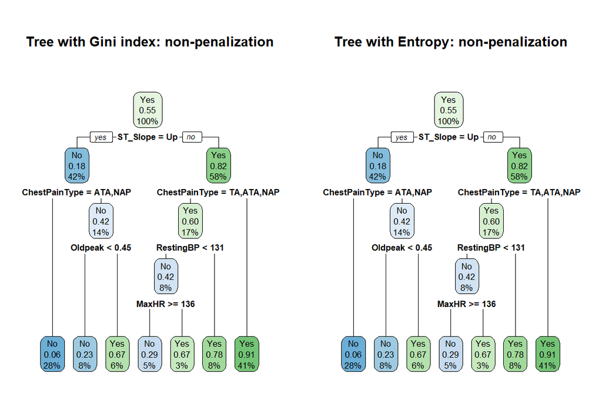

```r
library(rpart.plot)

gini.tree.11 <- tree.builder(in.data = trainData, fp = 1, fn = 1, purity = "gini")
info.tree.11 <- tree.builder(in.data = trainData, fp = 1, fn = 1, purity = "information")
gini.tree.110 <- tree.builder(in.data = trainData, fp = 1, fn = 10, purity = "gini")
info.tree.110 <- tree.builder(in.data = trainData, fp = 1, fn = 10, purity = "information")
gini.tree.101 <- tree.builder(in.data = trainData, fp = 10, fn = 1, purity = "gini")
info.tree.101 <- tree.builder(in.data = trainData, fp = 10, fn = 1, purity = "information")

par(mfrow=c(1,2))
rpart.plot(gini.tree.11, main = "Tree with Gini index: non-penalization")
rpart.plot(info.tree.11, main = "Tree with Entropy: non-penalization")
```

Due to the complexity of the decision trees that occurred post implementing the penalization, all subsequent decision trees were plotted separately. We can see how complex the tree gets once we start penalizing for errors. A continuous variable has the opportunity to be used in such a way that is different than a categorical one. The tree can allow for multiple values to be taken into consideration. We see that the split for ages appears twice and the age for the individual is different depending on where they are in the decision tree.

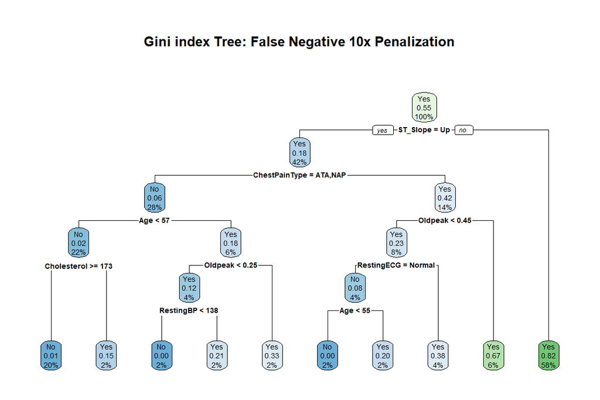

```r
library(rpart.plot)
rpart.plot(gini.tree.110, main = "Gini index Tree: False Negative 10x Penalization")
```

Additionally, we see that when we do a false negative penalization, the decision tree gets much more complex on the left side which is the ST_Slope: UP side (less likely to have Heart Disease)

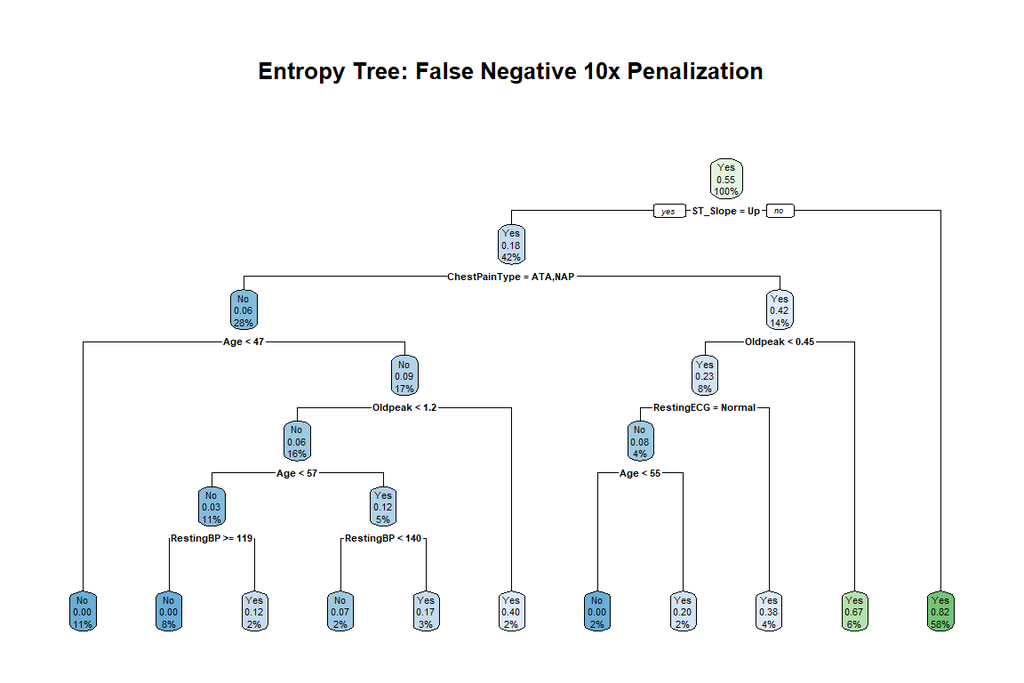

```r
rpart.plot(info.tree.110, main = "Entropy Tree: False Negative 10x Penalization")
```

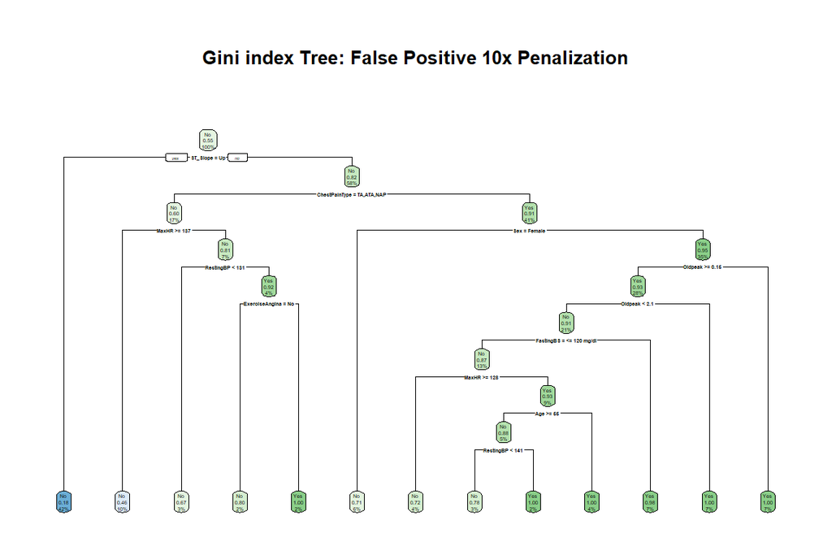

```r
rpart.plot(gini.tree.101, main = "Gini index Tree: False Positive 10x Penalization")
```

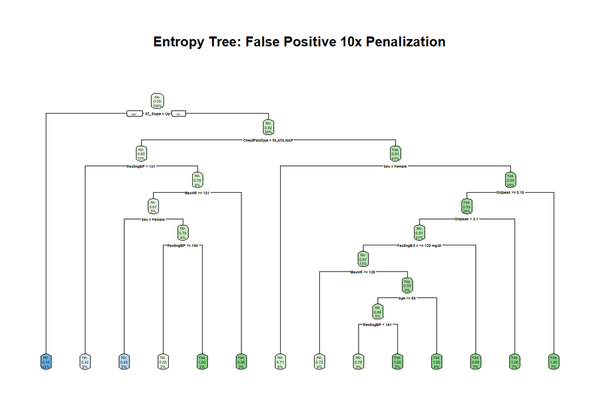

```r
rpart.plot(info.tree.101, main = "Entropy Tree: False Positive 10x Penalization")
```

We built 6 different decision tree models in the previous code chunks that showed very complex models when penalization is taken into account. These types are very important, especially in the world of medicine where a false negative could give the illusion that a person is healthy when they are really not. Next, we conducted ROC analysis which looks at the AUC to determine the best candidate model among the six. We can below that the non penalized model had the greatest AUC of 0.906

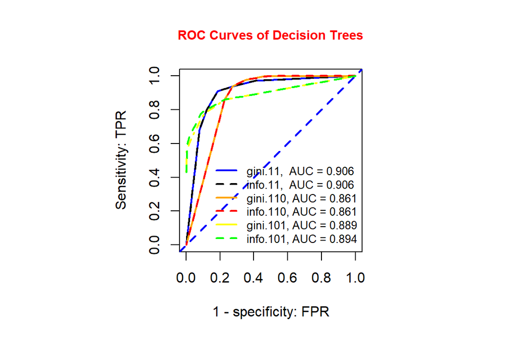

```r
SenSpe = function(in.data, fp, fn, purity) {
  cutoff = seq(0, 1, length = 20)

  model = tree.builder(in.data, fp, fn, purity)

  pred = predict(model, newdata = in.data, type = "prob")

  in.data$HeartDisease = factor(ifelse(in.data$HeartDisease == "Yes", 1, 0), levels = c(0, 1))

  senspe.mtx = matrix(0, ncol = length(cutoff), nrow = 2, byrow = FALSE)

  for (i in 1:length(cutoff)) {pred.out = ifelse(pred[, 2] >= cutoff[i], 1, 0)

    TP = sum(pred.out == 1 & in.data$HeartDisease == 1)
    TN = sum(pred.out == 0 & in.data$HeartDisease == 0)
    FP = sum(pred.out == 1 & in.data$HeartDisease == 0)
    FN = sum(pred.out == 0 & in.data$HeartDisease == 1)

    senspe.mtx[1, i] = TP / (TP + FN)
    senspe.mtx[2, i] = TN / (TN + FP)}

  category = factor(in.data$HeartDisease, levels = c(0, 1))

  prediction = pred[, 2]

  if (length(category) != length(prediction)) {stop("Length of response (target) and predictor (probabilities) do not match!")}

  ROCobj <- roc(category, prediction)
  AUC = auc(ROCobj)

  list(senspe.mtx = senspe.mtx, AUC = round(AUC, 3))}

giniROC11 = SenSpe(in.data = trainData, fp = 1, fn = 1, purity = "gini")
infoROC11 = SenSpe(in.data = trainData, fp = 1, fn = 1, purity = "information")
giniROC110 = SenSpe(in.data = trainData, fp = 1, fn = 10, purity = "gini")
infoROC110 = SenSpe(in.data = trainData, fp = 1, fn = 10, purity = "information")
giniROC101 = SenSpe(in.data = trainData, fp = 10, fn = 1, purity = "gini")
infoROC101 = SenSpe(in.data = trainData, fp = 10, fn = 1, purity = "information")

par(pty="s")
colors = c("Blue", "Black", "Orange", "Red", "Yellow", "Green")
plot(1 - giniROC11$senspe.mtx[2,], giniROC11$senspe.mtx[1,],
     type = "l",
     xlim = c(0, 1), ylim = c(0, 1),
     xlab = "1 - specificity: FPR", ylab = "Sensitivity: TPR",
     col = colors[1],
     lwd = 2,
     main = "ROC Curves of Decision Trees",
     cex.main = 0.9,
     col.main = "Red")
abline(0, 1, lty = 2, col = "Blue", lwd = 2)
lines(1 - infoROC11$senspe.mtx[2,], infoROC11$senspe.mtx[1,],
      col = colors[2], lwd = 2, lty = 2)
lines(1 - giniROC110$senspe.mtx[2,], giniROC110$senspe.mtx[1,],
      col = colors[3], lwd = 2)
lines(1 - infoROC110$senspe.mtx[2,], infoROC110$senspe.mtx[1,],
      col = colors[4], lwd = 2, lty = 2)
lines(1 - giniROC101$senspe.mtx[2,], giniROC101$senspe.mtx[1,],
      col = colors[5], lwd = 2, lty = 4)
lines(1 - infoROC101$senspe.mtx[2,], infoROC101$senspe.mtx[1,],
      col = colors[6], lwd = 2, lty = 2)
legend("bottomright", c(paste("gini.11,  AUC =", giniROC11$AUC),
                        paste("info.11,  AUC =", infoROC11$AUC),
                        paste("gini.110, AUC =", giniROC110$AUC),
                        paste("info.110, AUC =", infoROC110$AUC),
                        paste("gini.101, AUC =", giniROC101$AUC),
                        paste("info.101, AUC =", infoROC101$AUC)),
                        col = colors,
                        lty = rep(1:2, 3), lwd = rep(2, 6), cex = 0.8, bty = "n")
```

```r
predictions <- predict(gini.tree.11, newdata = testData, type = "class")

predictions <- factor(predictions, levels = levels(testData$HeartDisease))

conf_matrix <- confusionMatrix(predictions, testData$HeartDisease)

print(conf_matrix)
```

```
Confusion Matrix and Statistics

          Reference
Prediction  No Yes
       No   97  26
       Yes  23 129

               Accuracy : 0.8218
                 95% CI : (0.7714, 0.8652)
    No Information Rate : 0.5636
    P-Value [Acc > NIR] : <2e-16

                  Kappa : 0.6388

 Mcnemar's Test P-Value : 0.7751

            Sensitivity : 0.8083
            Specificity : 0.8323
         Pos Pred Value : 0.7886
         Neg Pred Value : 0.8487
             Prevalence : 0.4364
         Detection Rate : 0.3527
   Detection Prevalence : 0.4473
      Balanced Accuracy : 0.8203

       'Positive' Class : No
```

```r
accuracy <- conf_matrix$overall['Accuracy']
sensitivity <- conf_matrix$byClass['Sensitivity']
specificity <- conf_matrix$byClass['Specificity']
```

We still had the task to determine the optimal cut off and we see that each tree has their own optimal cut-off, and even within a single tree there may be several cut-offs which is ok. The average of the multiple cut-offs is a good method to choose as a final cut-off.

```r
library(rpart)
library(rpart.plot)

Optm.cutoff = function(in.data, fp, fn, purity){
  n0 = dim(in.data)[1] / 5
  cutoff = seq(0, 1, length = 20)

  accuracy.mtx = matrix(0, ncol = 20, nrow = 5)

  for (k in 1:5) {valid.id = ((k-1) * n0 + 1):(k * n0)
    valid.dat = in.data[valid.id, ]
    train.dat = in.data[-valid.id, ]

    tree.model = tree.builder(train.dat, fp, fn, purity)
    pred = predict(tree.model, newdata = valid.dat, type = "prob")[, 2]

    for (i in 1:20) {pc.1 = ifelse(pred > cutoff[i], "Yes", "No")

      a1 = mean(pc.1 == valid.dat$HeartDisease)
      accuracy.mtx[k, i] = a1}}
  avg.acc = apply(accuracy.mtx, 2, mean)

  n = length(avg.acc)
  idx = which(avg.acc == max(avg.acc))
  tick.label = as.character(round(cutoff, 2))

  plot(1:n, avg.acc, xlab = "Cut-off score", ylab = "Average accuracy",
       ylim = c(min(avg.acc), 1), axes = FALSE,
       main = paste("5-fold CV Optimal Cut-off \n", purity, "(fp, fn) = (", fp, ",", fn, ")"),
       cex.main = 0.9, col.main = "navy")
  axis(1, at = 1:20, label = tick.label, las = 2)
  axis(2)

  points(idx, avg.acc[idx], pch = 19, col = "red")
  segments(idx, min(avg.acc), idx, avg.acc[idx], col = "red")
  text(idx, avg.acc[idx] + 0.03, as.character(round(avg.acc[idx], 4)),
       col = "red", cex = 0.8)}

par(mfrow = c(3, 2))
```

The code chunks were split to give a better visualization as the graphs were very difficult to examine closely given the size restriction. We see the Average accuracy of the non penalized models were higher than those of the penalized models.

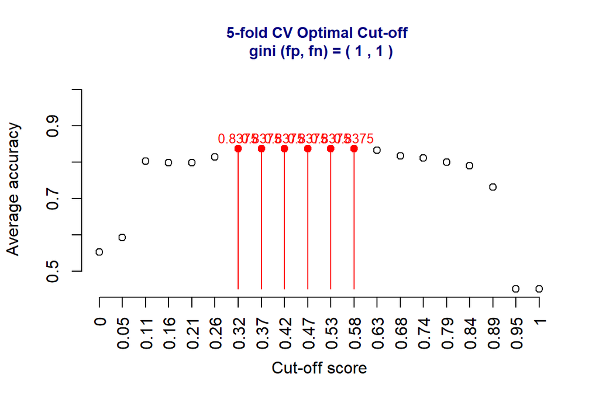

```r
Optm.cutoff(in.data = trainData, fp = 1, fn = 1, purity = "gini")
```

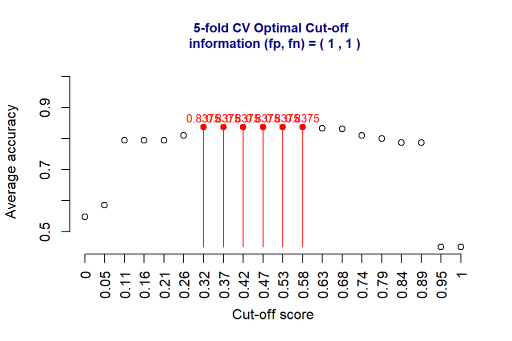

```r
Optm.cutoff(in.data = trainData, fp = 1, fn = 1, purity = "information")
```

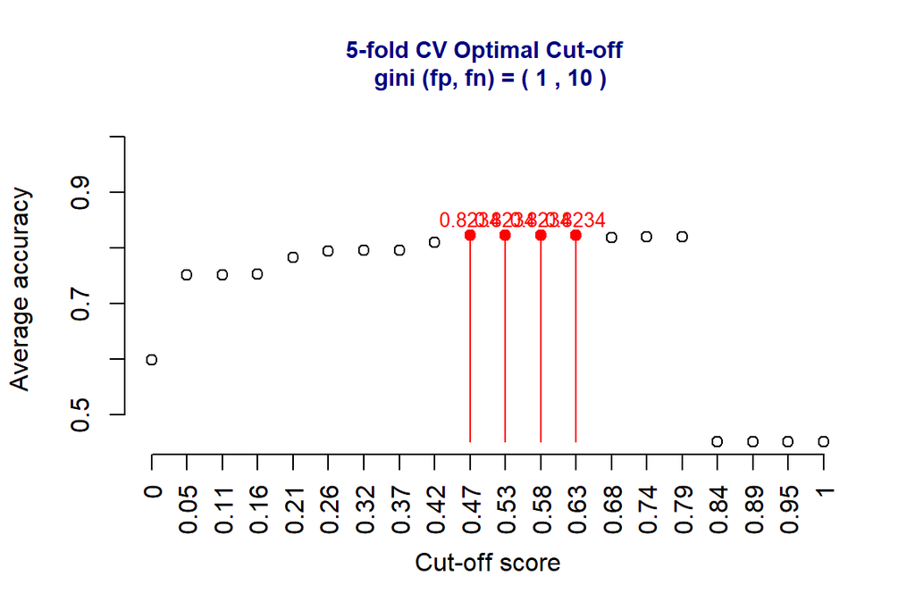

```r
Optm.cutoff(in.data = trainData, fp = 1, fn = 10, purity = "gini")
```

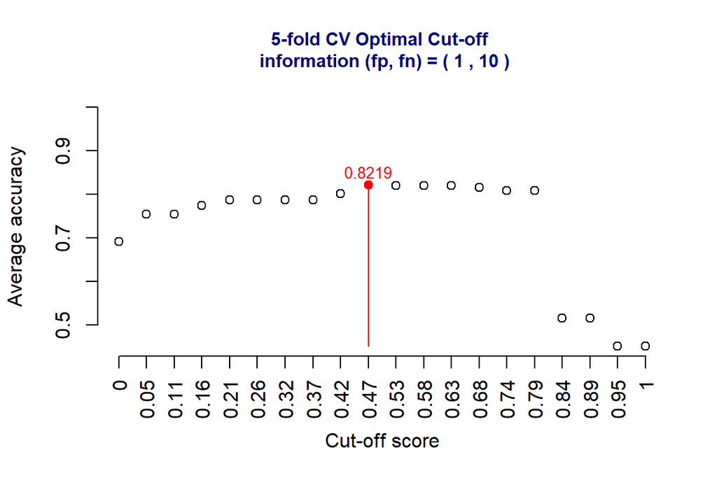

```r
Optm.cutoff(in.data = trainData, fp = 1, fn = 10, purity = "information")
```

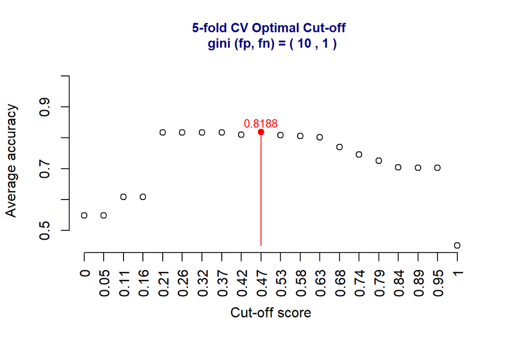

```r
Optm.cutoff(in.data = trainData, fp = 10, fn = 1, purity = "gini")
```

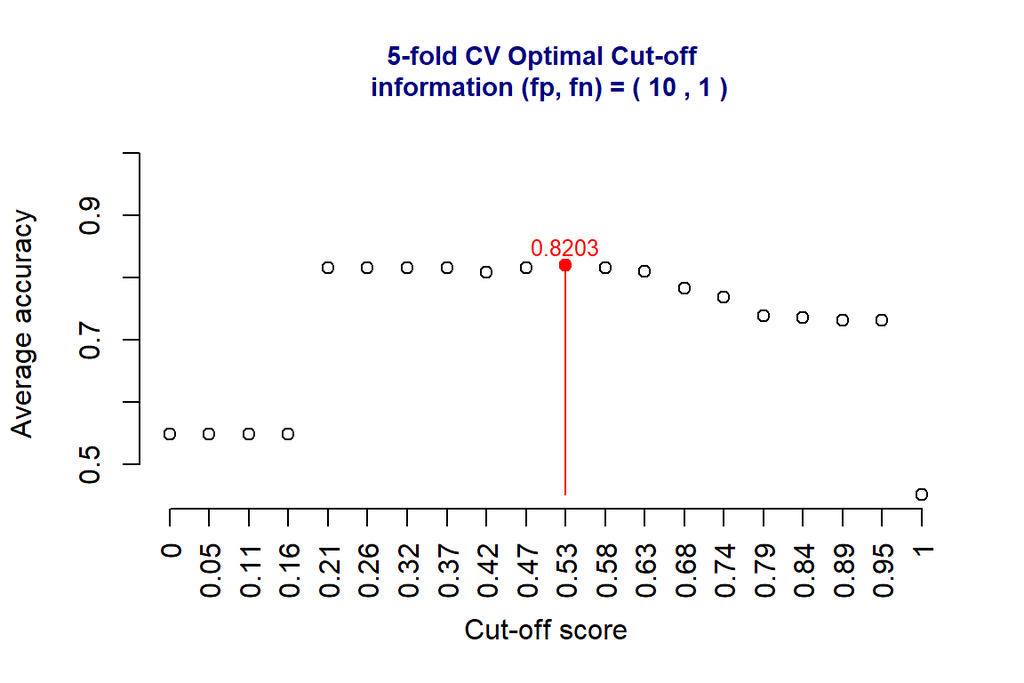

```r
Optm.cutoff(in.data = trainData, fp = 10, fn = 1, purity = "information")
```

## 4.4 Bootstrap Method

The last statistical technique that we implemented that was mentioned in the introduction was the Bootstrap Method. As previously noted, this is a method that assumes our dataset is representative of the population and the dataset is large enough such that the empirical distribution can approximate the true distribution. These assumptions allowed us to perform the technique which is resampling the data with replacement to allow us to estimate the true distribution.

### 4.4.1 Bootstrap Method for Assessing AUC in Logistic Regression

Below we used a new dataset heart_data and ran 1000 bootstrap samples to help assess the AUC for the logistic regression model predicting HeartDisase. The resulting histogram provides a good example of the distribution of the AUC values for the 1000 bootstrap samples.

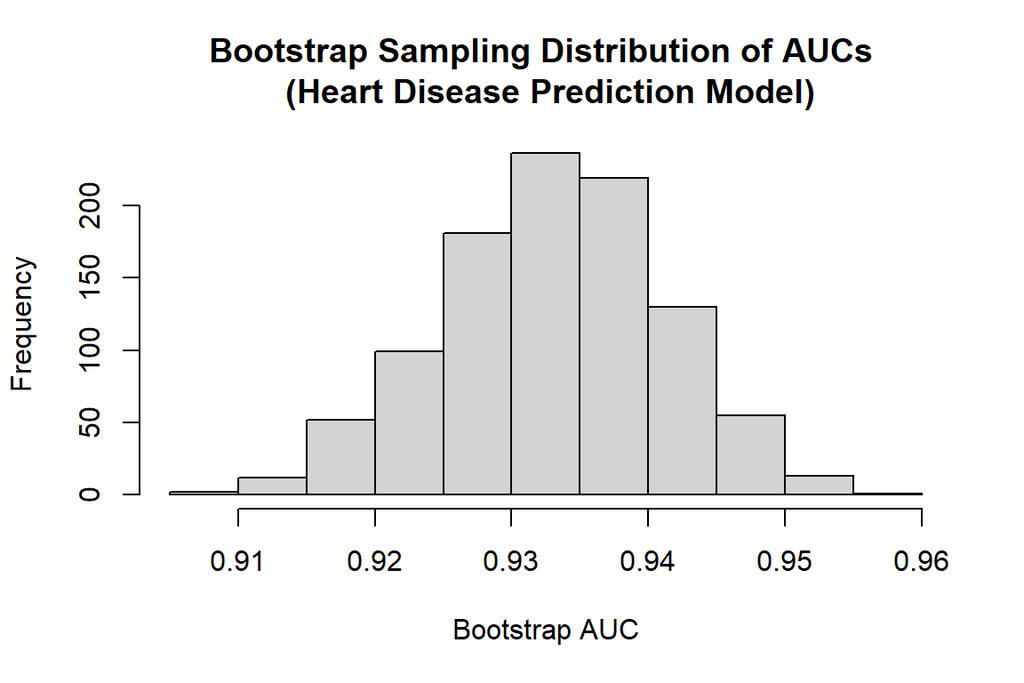

```r
heart_data <- Heart

heart_data$status = ifelse(heart_data$HeartDisease == "Yes", "yes", "no")

btAUC.vec = c()

B = 1000

sample.size = dim(heart_data)[1]

cut.off.seq = seq(0, 1, length = 100)

for (k in 1:B) {
  boot.id = sample(1:sample.size, sample.size, replace = TRUE)
  boot.sample = heart_data[boot.id, ]

  boot.logistic = glm(factor(status) ~ Age + Sex + ChestPainType + RestingBP + Cholesterol +
                        FastingBS + RestingECG + MaxHR + ExerciseAngina + Oldpeak + ST_Slope,
                      family = binomial, data = boot.sample)

  pred.prob = predict.glm(boot.logistic, newdata = boot.sample, type = "response")

  sensitivity.vec = NULL
  specificity.vec = NULL

  for (i in 1:100) {
    pred.status = as.numeric(pred.prob > cut.off.seq[i])
    TN = sum(pred.status == 0 & boot.sample$status == "no")
    FN = sum(pred.status == 0 & boot.sample$status == "yes")
    FP = sum(pred.status == 1 & boot.sample$status == "no")
    TP = sum(pred.status == 1 & boot.sample$status == "yes")

    sensitivity.vec[i] = TP / (TP + FN)
    specificity.vec[i] = TN / (TN + FP)}

  one.minus.spec = 1 - specificity.vec
  sens.vec = sensitivity.vec

  prediction = pred.prob
  category = boot.sample$status == "yes"
  ROCobj <- roc(category, prediction)
  btAUC.vec[k] = round(auc(ROCobj), 4)}

hist(btAUC.vec, xlab = "Bootstrap AUC", main = "Bootstrap Sampling Distribution of AUCs \n (Heart Disease Prediction Model)")
```

The 95% bootstrap confidence interval of the AUC is defined to be 2.5% and 97.5% quantiles of the bootstrap AUCs which can be seen below via the pander function. The confidence interval of AUC can be useful for variable selection given if two confidence intervals of AUC overlapped. The predictive performances of the two corresponding predictive models are not significantly different. A simpler model would be recommended as a replacement

```r
pander(quantile(btAUC.vec, c(0.025, 0.975)))
```

| 2.5% | 97.5% |
| --- | --- |
| 0.9164 | 0.9482 |